# PCA_Revised_Bacteria_27K

Cassandra Sperow

2023-10-01

# Principal Components Analysis for Revised 27K Bacteria

- Goal: Find groups of bacteria that tend to be together
- Method: Principal Components Analysis (PCA) which is an unsupervised machine learning technique

## Read in Revised Data Frame

- Revised bacteria data have 5,890 ASV columns vs. the original 33K.
- See “Bacteria ASV Table EDA.Rmd” for details

```r
# read in revised bacteria df with only 5,890 ASV columns (not 33K)
read_csv("../output/rev_bacteria.csv") -> rev_bacteria
```

## Test PCA for Scaled Data

```r
stats::prcomp(rev_bacteria[,-1], scale. = T) -> pca_out
```

```r
pca_out %>% glimpse()
```

```
## List of 5
##  $ sdev    : num [1:659] 13.55 11.19 8.66 8.28 8.21 ...
##  $ rotation: num [1:5889, 1:659] -0.004292 -0.007366 -0.000974 -0.007596 -0.005901 ...
##   ..- attr(*, "dimnames")=List of 2
##   .. ..$ : chr [1:5889] "ASV0001" "ASV0002" "ASV0003" "ASV0004" ...
##   .. ..$ : chr [1:659] "PC1" "PC2" "PC3" "PC4" ...
##  $ center  : Named num [1:5889] 8892 8002 7034 5809 4148 ...
##   ..- attr(*, "names")= chr [1:5889] "ASV0001" "ASV0002" "ASV0003" "ASV0004" ...
##  $ scale   : Named num [1:5889] 18311 17496 15912 12135 9288 ...
##   ..- attr(*, "names")= chr [1:5889] "ASV0001" "ASV0002" "ASV0003" "ASV0004" ...
##  $ x       : num [1:659, 1:659] -0.623 -2.836 -3.114 -1.797 -1.902 ...
##   ..- attr(*, "dimnames")=List of 2
##   .. ..$ : NULL
##   .. ..$ : chr [1:659] "PC1" "PC2" "PC3" "PC4" ...
##  - attr(*, "class")= chr "prcomp"
```

```r
summary(pca_out) -> pca_out_summary

glimpse(pca_out_summary)
```

```
## List of 6
##  $ sdev      : num [1:659] 13.55 11.19 8.66 8.28 8.21 ...
##  $ rotation  : num [1:5889, 1:659] -0.004292 -0.007366 -0.000974 -0.007596 -0.005901 ...
##   ..- attr(*, "dimnames")=List of 2
##   .. ..$ : chr [1:5889] "ASV0001" "ASV0002" "ASV0003" "ASV0004" ...
##   .. ..$ : chr [1:659] "PC1" "PC2" "PC3" "PC4" ...
##  $ center    : Named num [1:5889] 8892 8002 7034 5809 4148 ...
##   ..- attr(*, "names")= chr [1:5889] "ASV0001" "ASV0002" "ASV0003" "ASV0004" ...
##  $ scale     : Named num [1:5889] 18311 17496 15912 12135 9288 ...
##   ..- attr(*, "names")= chr [1:5889] "ASV0001" "ASV0002" "ASV0003" "ASV0004" ...
##  $ x         : num [1:659, 1:659] -0.623 -2.836 -3.114 -1.797 -1.902 ...
##   ..- attr(*, "dimnames")=List of 2
##   .. ..$ : NULL
##   .. ..$ : chr [1:659] "PC1" "PC2" "PC3" "PC4" ...
##  $ importance: num [1:3, 1:659] 13.5539 0.0312 0.0312 11.1914 0.0213 ...
##   ..- attr(*, "dimnames")=List of 2
##   .. ..$ : chr [1:3] "Standard deviation" "Proportion of Variance" "Cumulative Proportion"
##   .. ..$ : chr [1:659] "PC1" "PC2" "PC3" "PC4" ...
##  - attr(*, "class")= chr "summary.prcomp"
```

- From the summary of the PCA results, the output is hard to read because there are 659 samples.
- Need to review the ‘importance’ part of the summary results:

```r
# glimpsing the nested df of the importances from the summary()
pca_out_summary$importance %>% glimpse()
```

```
##  num [1:3, 1:659] 13.5539 0.0312 0.0312 11.1914 0.0213 ...
##  - attr(*, "dimnames")=List of 2
##   ..$ : chr [1:3] "Standard deviation" "Proportion of Variance" "Cumulative Proportion"
##   ..$ : chr [1:659] "PC1" "PC2" "PC3" "PC4" ...
```

- Create a separate df for the ‘importance’ aspect of the summary of the PCA results to review the standard deviations, proportions of variance explained, and the cumulative proportions because we need to see how many components explain at least 80 % of the variability in the X matrix of bacteria:

```r
# from above, the importance results have the following names per PC 1-659
names_pca_out <- c("Standard deviation" ,"Proportion of Variance", "Cumulative Proportion")

# using the names above to make the same
bind_cols(
pca_out_name = names_pca_out,
pca_out_summary$importance
) -> importance_df
```

- How many PCs explain at least 80 % ?

```r
importance_df %>%
  # pivoting data drame so that cumulatives are in column
  t() %>%  as.data.frame() %>%
  # moving up top row as column header
  janitor::row_to_names(1) %>% ######## snapshot here for presentation
  # filtering cumulative proportion column for greater > = 80 %
  filter(`Cumulative Proportion` >= 0.8)
```

```
##       Standard deviation Proportion of Variance Cumulative Proportion
## PC239           2.679221               0.001220              0.800160
## PC240           2.677004               0.001220              0.801370
## PC241           2.672194               0.001210              0.802590
## PC242           2.659232               0.001200              0.803790
## PC243           2.654783               0.001200              0.804980
## PC244           2.650518               0.001190              0.806180
## PC245           2.641862               0.001190              0.807360
## PC246            2.63549                0.00118               0.80854
## PC247           2.625074               0.001170              0.809710
## PC248           2.620541               0.001170              0.810880
## PC249           2.618658               0.001160              0.812040
## PC250           2.608964               0.001160              0.813200
## PC251           2.606389               0.001150              0.814350
## PC252            2.59941                0.00115               0.81550
## PC253           2.596816               0.001150              0.816640
## PC254           2.582472               0.001130              0.817780
## PC255           2.574506               0.001130              0.818900
## PC256            2.56400                0.00112               0.82002
## PC257           2.561195               0.001110              0.821130
## PC258           2.556086               0.001110              0.822240
## PC259           2.548641               0.001100              0.823340
## PC260           2.538123               0.001090              0.824440
## PC261           2.534924               0.001090              0.825530
## PC262           2.528737               0.001090              0.826620
## PC263           2.527728               0.001080              0.827700
## PC264           2.514945               0.001070              0.828770
## PC265           2.511636               0.001070              0.829850
## PC266           2.502851               0.001060              0.830910
## PC267           2.499765               0.001060              0.831970
## PC268           2.498341               0.001060              0.833030
## PC269           2.490198               0.001050              0.834080
## PC270           2.485715               0.001050              0.835130
## PC271           2.480863               0.001050              0.836180
## PC272            2.47343                0.00104               0.83722
## PC273           2.465354               0.001030              0.838250
## PC274           2.450971               0.001020              0.839270
## PC275           2.446496               0.001020              0.840280
## PC276           2.442073               0.001010              0.841300
## PC277           2.436871               0.001010              0.842310
```

[output cut: 367 more lines]

```
## PC645          0.2841987              0.0000100             0.9999400
## PC646          0.2621732              0.0000100             0.9999500
## PC647          0.2491057              0.0000100             0.9999600
## PC648          0.2094051              0.0000100             0.9999700
## PC649          0.1997542              0.0000100             0.9999700
## PC650          0.1921163              0.0000100             0.9999800
## PC651          0.1599413              0.0000000             0.9999900
## PC652          0.1509871              0.0000000             0.9999900
## PC653          0.1360659              0.0000000             0.9999900
## PC654          0.1220435              0.0000000             0.9999900
## PC655           0.113692               0.000000              1.000000
## PC656         0.09910304             0.00000000            1.00000000
## PC657         0.07286339             0.00000000            1.00000000
## PC658          0.0378262              0.0000000             1.0000000
## PC659        9.83761e-15            0.00000e+00           1.00000e+00
```

- About 239 principal components explain 80 % of cumulative variance in the X matrix of only the 5K bacteria
- The number of principal components may be used as the number of `k` clusters to look for in K-Means clustering:

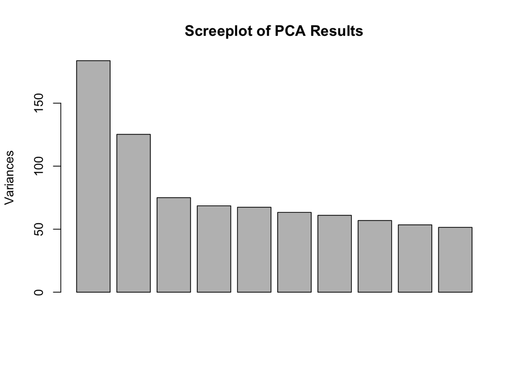

```r
screeplot(pca_out, main = "Screeplot of PCA Results")
```

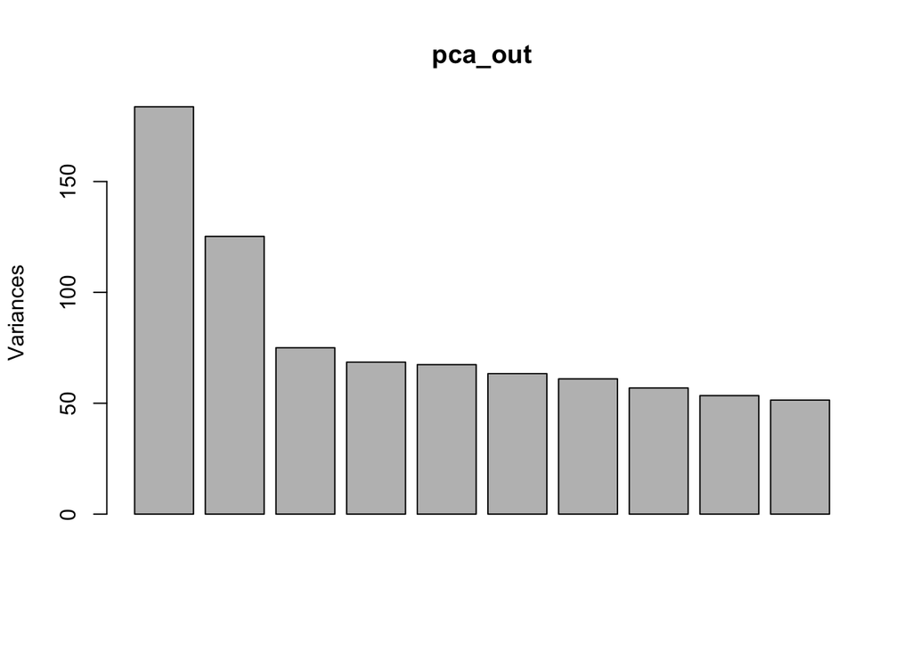

```r
plot(pca_out)
```

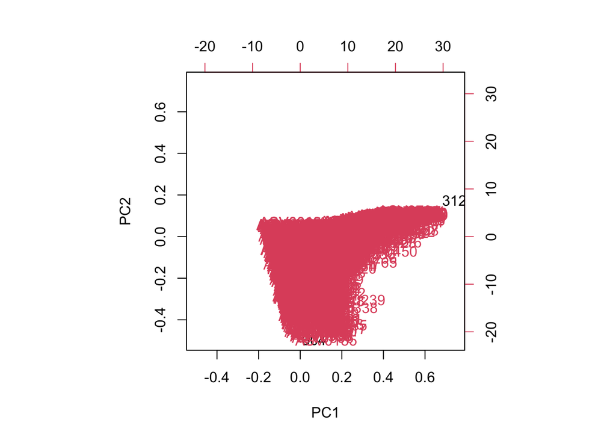

```r
biplot(pca_out,
      # scale = 0,
      # cex = c(1, 1.3)
      # expand = 10,
      # choices = 3:4
      # xlim = c(-0.002, 0.002), ylim = c(-0.001, 0.001)

       )
```

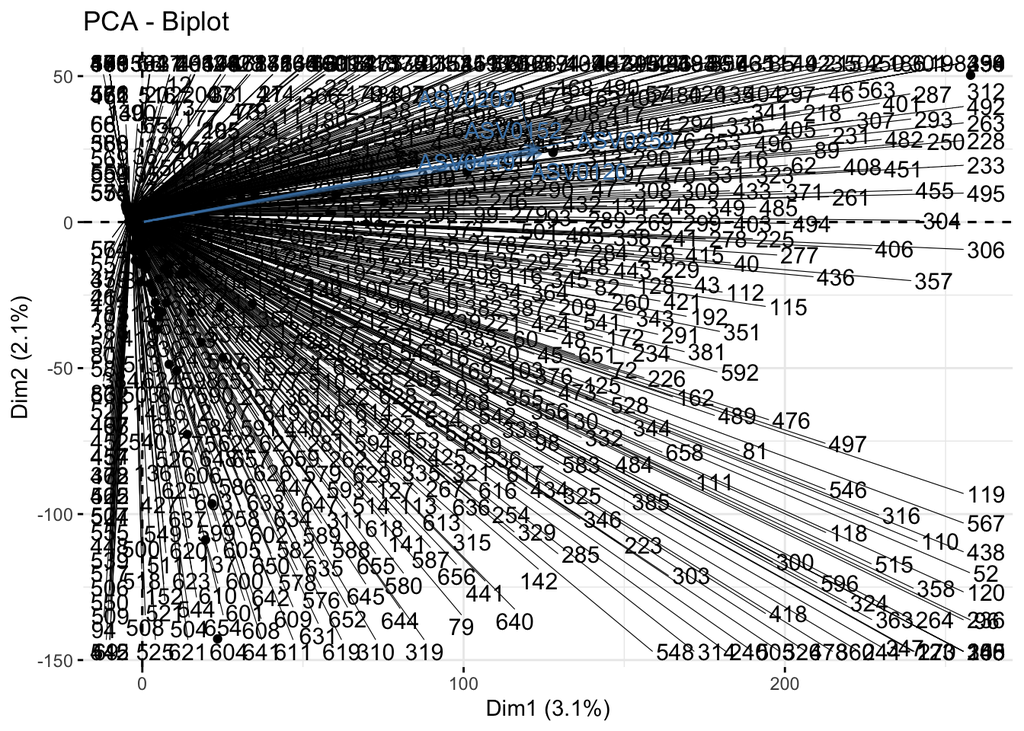

```r
factoextra::fviz_pca_biplot(pca_out, repel = T,
                            alpha.var = 0.5,
                            select.var = list(contrib = 5), # top 5 contributors are blue arrows in the plot amongst others
                          #  xlim = c(-100, 300),
                          #  ylim = c(),
                            xlabs=rep("*", nrow(rev_bacteria))
)
```

- Obtain simpler plot of first 2 components using indexing from ‘x’ in pca_out object:

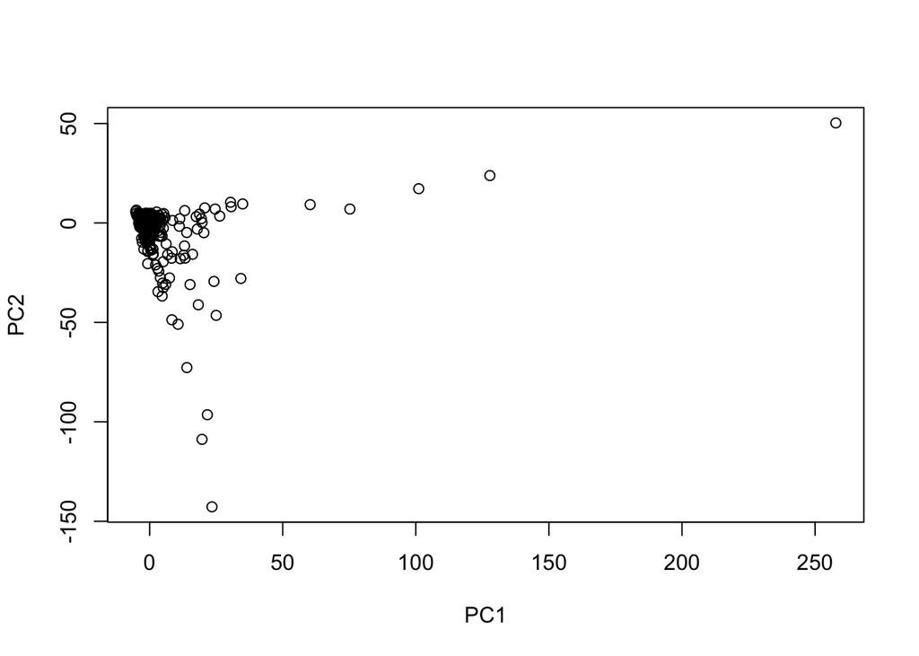

```r
# pch argument is for making points not regular viz from pca object
plot(pca_out$x[,1:2], pch=1)
```

```r
library(plotly)
library(ggfortify)
```

```r
class(pca_out)
```

```
## [1] "prcomp"
```

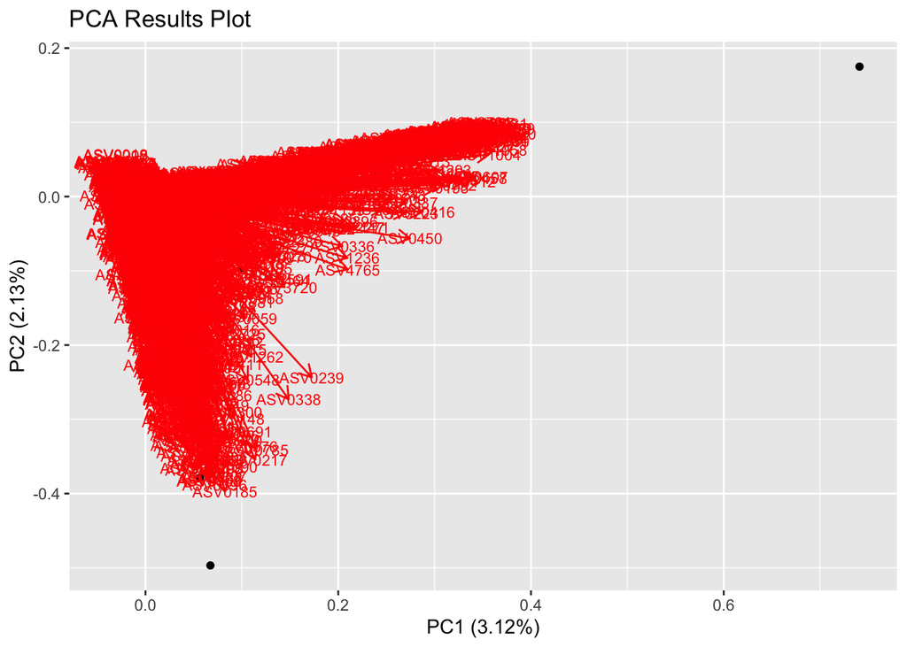

```r
pca_out %>% autoplot(loadings = T,
                     loadings.label = T,
                     loadings.label.size = 3,
                     repel = T,
                     main = "PCA Results Plot",
)
```

Documentation: https://search.r-project.org/CRAN/refmans/factoextra/html/fviz_pca.html

- Graph of Indivdiuals:

```r
library(factoextra)
```

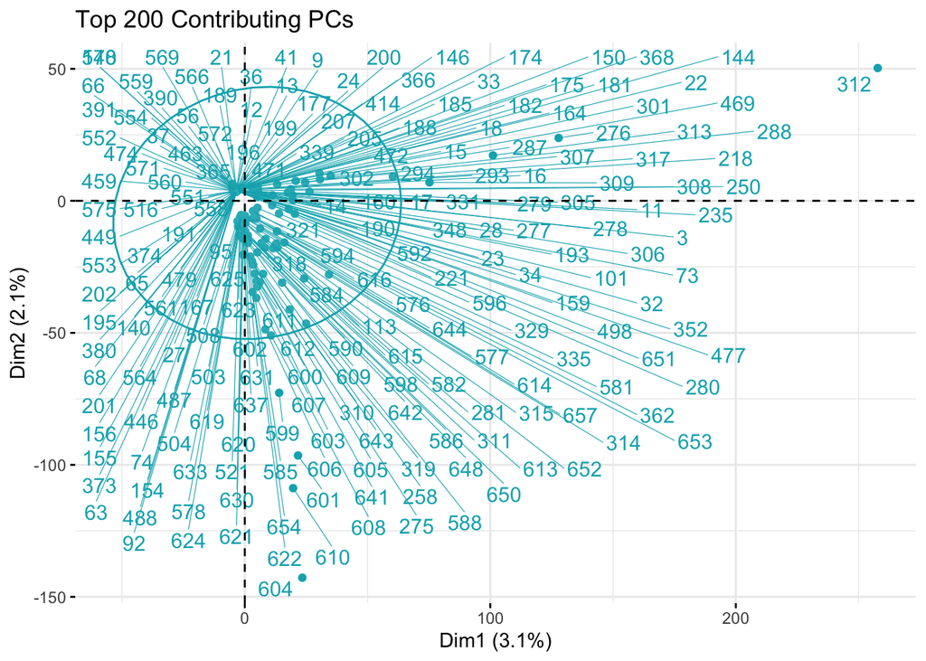

```r
fviz_pca_ind(pca_out,
             select.ind = list(contrib = 200),
             col.ind = "#00AFBB",
             addEllipses=TRUE, ellipse.level=0.95,
             #palette = "Dark2",
            # palette = c("#999999", "#E69F00", "#56B4E9"),
             repel = TRUE,
            #label = "none",
            title = "Top 200 Contributing PCs")
```

- Graph of Variables:

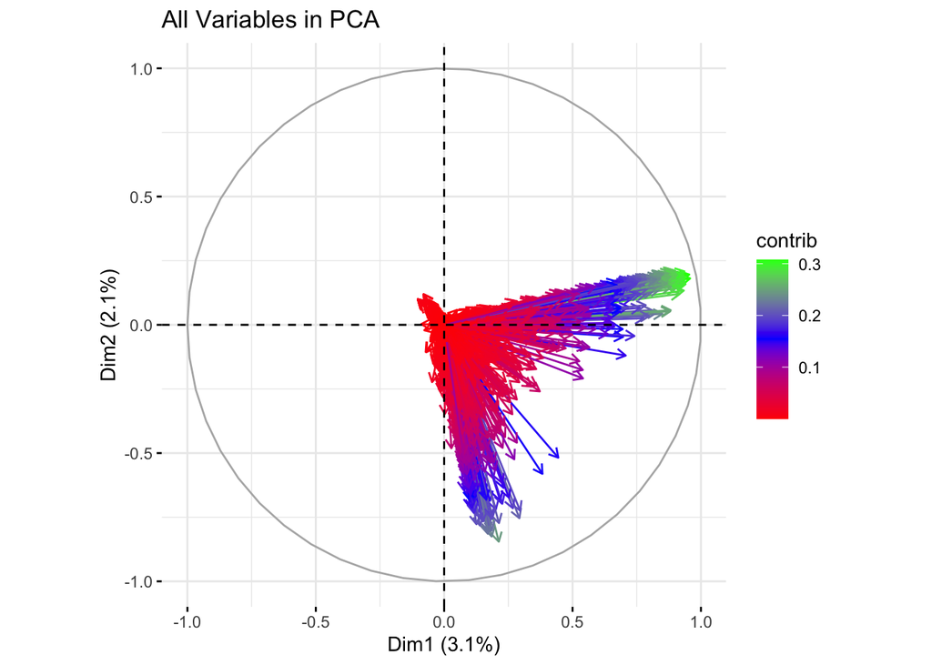

```r
fviz_pca_var(pca_out,
             #col.var = "steelblue",
             col.var = "contrib",
             gradient.cols = c("red", "blue", "green"),
            # repel = T,
            label = "none",
             title = "All Variables in PCA")
```

- Since there are so many that have the same standard deviation and individual proportional, it may be useful to see the distribution of these, especially since the screeplot only gives first 10:

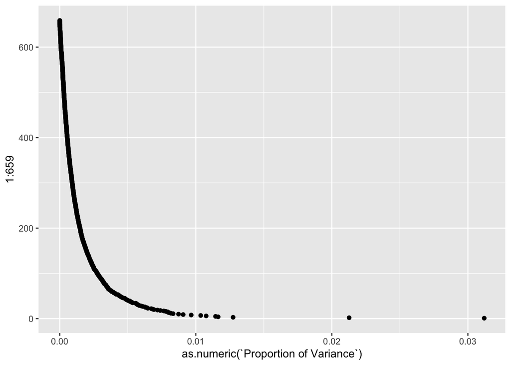

```r
importance_df %>%
  t() %>% as.data.frame() %>%
  janitor::row_to_names(1) %>%
  ggplot(aes(x = as.numeric(`Proportion of Variance`), y = 1:659)) +
  geom_point()
```

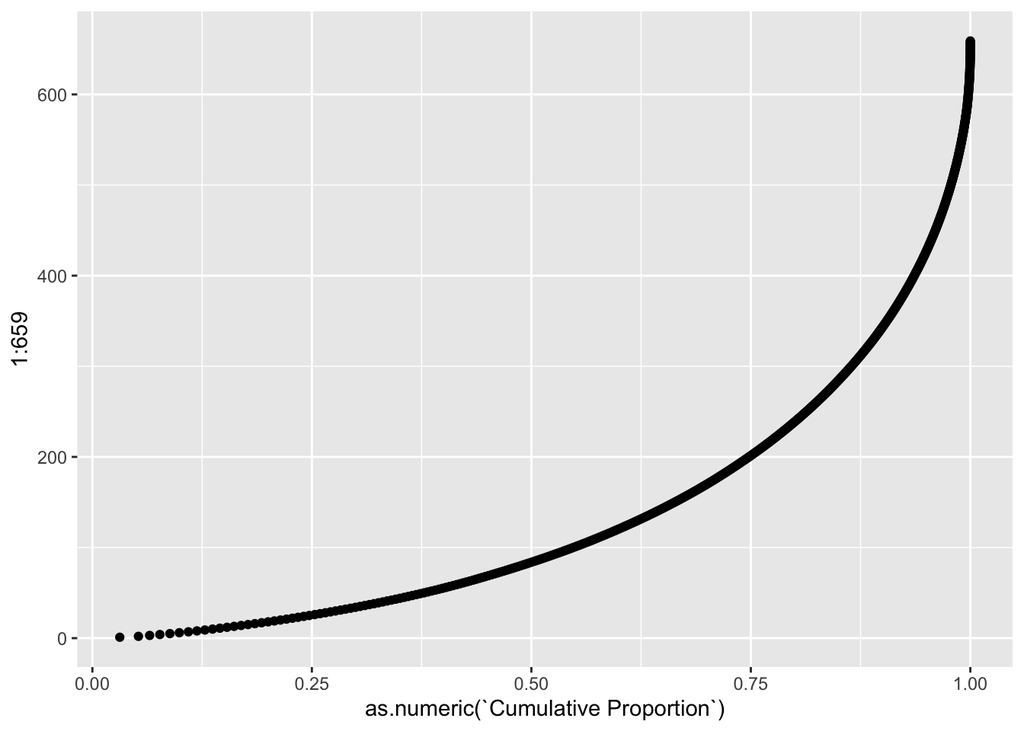

```r
importance_df %>%
  t() %>% as.data.frame() %>%
  janitor::row_to_names(1) %>%
  ggplot(aes(x = as.numeric(`Cumulative Proportion`), y = 1:659)) +
  geom_point()
```

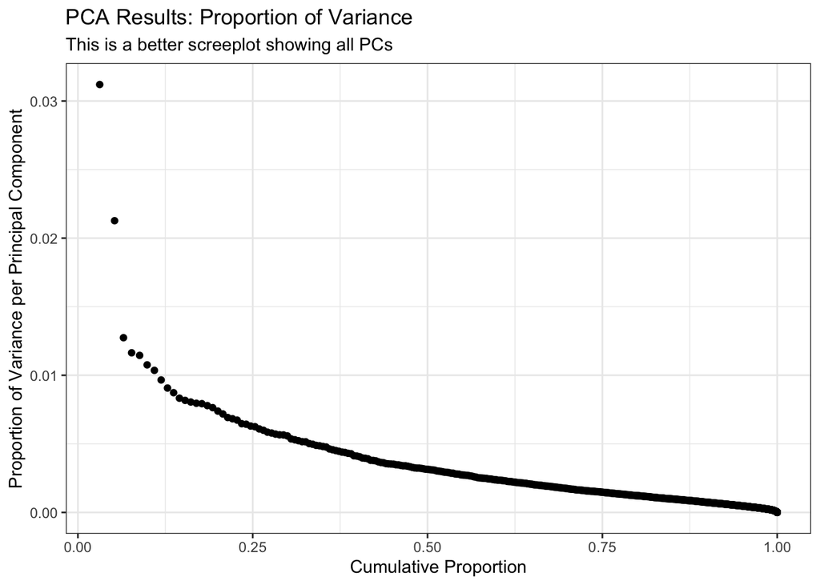

```r
importance_df %>%
  t() %>% as.data.frame() %>%
  janitor::row_to_names(1) %>%
  ggplot(aes(x = as.numeric(`Cumulative Proportion`) , y =  as.numeric(`Proportion of Variance`))) +
  geom_point() +
  ggtitle("PCA Results: Proportion of Variance", "This is a better screeplot showing all PCs") +
  xlab("Cumulative Proportion") +
  ylab("Proportion of Variance per Principal Component") +
  theme_bw()
```

Interpretation: This acts as a more informative screeplot that shows how the proportion of variance exponentially decreases.